# Data Analysis Assignment #1 (50 points total)

Kim, Tae-Seung

Submit both the .Rmd and .html files for grading. You may remove the instructions and example problem above, but do not remove the YAML metadata block or the first, “setup” code chunk. Address the steps that appear below and answer all the questions. Be sure to address each question with code and comments as needed. You may use either base R functions or ggplot2 for the visualizations.

The following code chunk will:

1. load the “ggplot2”, “gridExtra” and “knitr” packages, assuming each has been installed on your machine,
2. read-in the abalones dataset, defining a new data frame, “mydata,”
3. return the structure of that data frame, and
4. calculate new variables, VOLUME and RATIO.

Do not include package installation code in this document. Packages should be installed via the Console or ‘Packages’ tab. You will also need to download the abalones.csv from the course site to a known location on your machine. Unless a *file.path()* is specified, R will look to directory where this .Rmd is stored when knitting.

```
## 'data.frame':    1036 obs. of  8 variables:
##  $ SEX   : Factor w/ 3 levels "F","I","M": 2 2 2 2 2 2 2 2 2 2 ...
##  $ LENGTH: num  5.57 3.67 10.08 4.09 6.93 ...
##  $ DIAM  : num  4.09 2.62 7.35 3.15 4.83 ...
##  $ HEIGHT: num  1.26 0.84 2.205 0.945 1.785 ...
##  $ WHOLE : num  11.5 3.5 79.38 4.69 21.19 ...
##  $ SHUCK : num  4.31 1.19 44 2.25 9.88 ...
##  $ RINGS : int  6 4 6 3 6 6 5 6 5 6 ...
##  $ CLASS : Factor w/ 5 levels "A1","A2","A3",..: 1 1 1 1 1 1 1 1 1 1 ...
```

### Test Items starts from here - There are 6 sections - Total 50 points

*##### Section 1: (6 points) Summarizing the data.*

(1)(a) (1 point) Use *summary()* to obtain and present descriptive statistics from mydata. Use *table()* to present a frequency table using CLASS and RINGS. There should be 115 cells in the table you present.

```
##  SEX         LENGTH           DIAM            HEIGHT          WHOLE
##  F:326   Min.   : 2.73   Min.   : 1.995   Min.   :0.525   Min.   :  1.625
##  I:329   1st Qu.: 9.45   1st Qu.: 7.350   1st Qu.:2.415   1st Qu.: 56.484
##  M:381   Median :11.45   Median : 8.925   Median :2.940   Median :101.344
##          Mean   :11.08   Mean   : 8.622   Mean   :2.947   Mean   :105.832
##          3rd Qu.:13.02   3rd Qu.:10.185   3rd Qu.:3.570   3rd Qu.:150.319
##          Max.   :16.80   Max.   :13.230   Max.   :4.935   Max.   :315.750
##      SHUCK              RINGS        CLASS        VOLUME
##  Min.   :  0.5625   Min.   : 3.000   A1:108   Min.   :  3.612
##  1st Qu.: 23.3006   1st Qu.: 8.000   A2:236   1st Qu.:163.545
##  Median : 42.5700   Median : 9.000   A3:329   Median :307.363
##  Mean   : 45.4396   Mean   : 9.993   A4:188   Mean   :326.804
##  3rd Qu.: 64.2897   3rd Qu.:11.000   A5:175   3rd Qu.:463.264
##  Max.   :157.0800   Max.   :25.000            Max.   :995.673
##      RATIO
##  Min.   :0.06734
##  1st Qu.:0.12241
##  Median :0.13914
##  Mean   :0.14205
##  3rd Qu.:0.15911
##  Max.   :0.31176
```

```
##
##        3   4   5   6   7   8   9  10  11  12  13  14  15  16  17  18  19  20
##   A1   9   8  24  67   0   0   0   0   0   0   0   0   0   0   0   0   0   0
##   A2   0   0   0   0  91 145   0   0   0   0   0   0   0   0   0   0   0   0
##   A3   0   0   0   0   0   0 182 147   0   0   0   0   0   0   0   0   0   0
##   A4   0   0   0   0   0   0   0   0 125  63   0   0   0   0   0   0   0   0
##   A5   0   0   0   0   0   0   0   0   0   0  48  35  27  15  13   8   8   6
##
##       21  22  23  24  25
##   A1   0   0   0   0   0
##   A2   0   0   0   0   0
##   A3   0   0   0   0   0
##   A4   0   0   0   0   0
##   A5   4   1   7   2   1
```

**Question (1 point): Briefly discuss the variable types and distributional implications such as potential skewness and outliers.**

SEX is almost balanced, there is a slightly higher number of M so that may need to be adjust via weighting. CLASS is a bit more unbalanced. Looks like a normal distribution for A1-5. Further investigation will reveal skewness.

WHOLE, SHUCK, RINGS, and VOLUME look like there could be a lot of outliers just based on how big the max is versus the 3rd quartile.

(1)(b) (1 point) Generate a table of counts using SEX and CLASS. Add margins to this table (Hint: There should be 15 cells in this table plus the marginal totals. Apply *table()* first, then pass the table object to *addmargins()* (Kabacoff Section 7.2 pages 144-147)). Lastly, present a barplot of these data; ignoring the marginal totals.

```
##
##      A1  A2  A3  A4  A5
##   F   5  41 121  82  77
##   I  91 133  65  21  19
##   M  12  62 143  85  79
```

```
## Margins computed over dimensions
## in the following order:
## 1:
## 2:
```

```
##
##         A1   A2   A3   A4   A5  sum
##   F      5   41  121   82   77  326
##   I     91  133   65   21   19  329
##   M     12   62  143   85   79  381
##   sum  108  236  329  188  175 1036
```

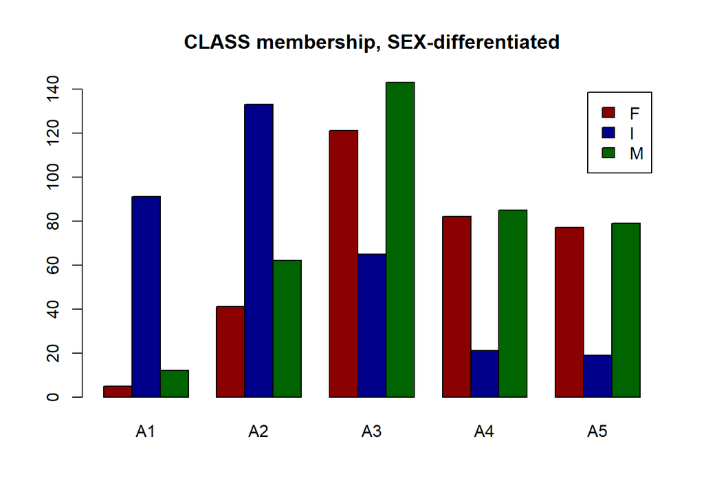

**Essay Question (2 points): Discuss the sex distribution of abalones. What stands out about the distribution of abalones by CLASS?**

The distribution of abalones are positively skewed (right skew) for Infants. Infants dominate the A1/A2 classes heavily which makes since considering that infants of anything are smaller than adults.

For Males and Females, we see the opposite where they’re negatively skewed (left skew). This again makes sense where adults are larger than infants.

Outliers in both groups contribute to the skewness with abnormally large infants in A4/A5 and abnormally small adults in A1/A2.

*(1)(c) (1 point)* Select a simple random sample of 200 observations from “mydata” and identify this sample as “work.” Use *set.seed(123)* prior to drawing this sample. Do not change the number 123. Note that *sample()* “takes a sample of the specified size from the elements of x.” We cannot sample directly from “mydata.” Instead, we need to sample from the integers, 1 to 1036, representing the rows of “mydata.” Then, select those rows from the data frame (Kabacoff Section 4.10.5 page 87).

Using “work”, construct a scatterplot matrix of variables 2-6 with *plot(work[, 2:6])* (these are the continuous variables excluding VOLUME and RATIO). The sample “work” will not be used in the remainder of the assignment.

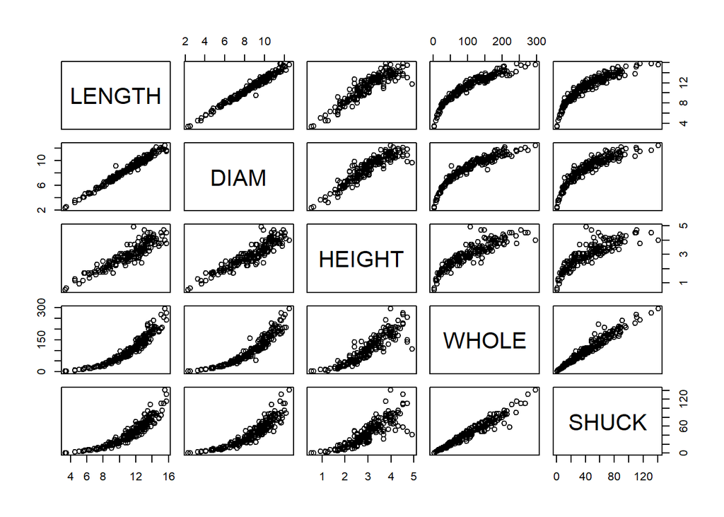

*##### Section 2: (5 points) Summarizing the data using graphics.*

(2)(a) (1 point) Use “mydata” to plot WHOLE versus VOLUME. Color code data points by CLASS.

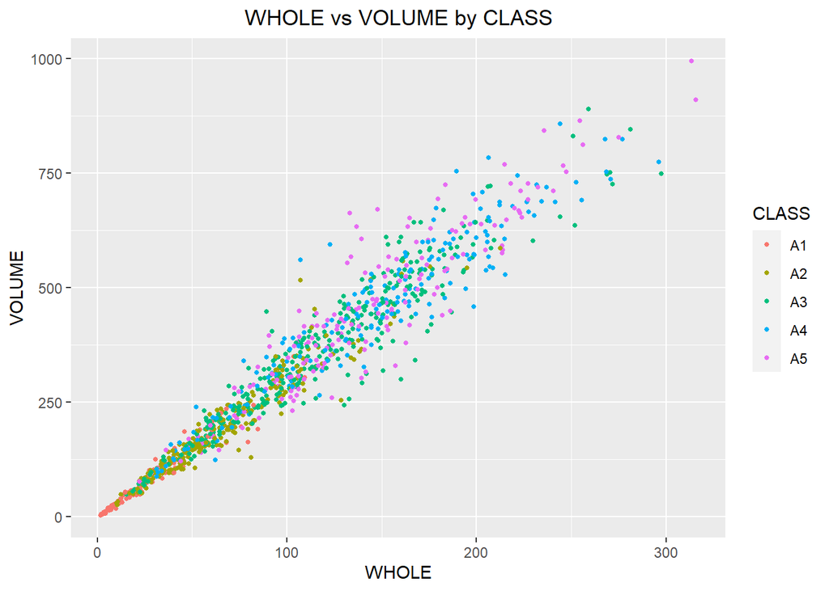

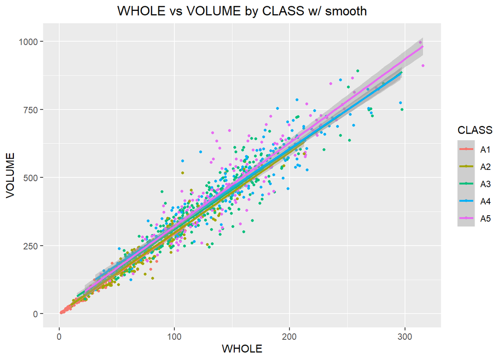

(2)(b) (2 points) Use “mydata” to plot SHUCK versus WHOLE with WHOLE on the horizontal axis. Color code data points by CLASS. As an aid to interpretation, determine the maximum value of the ratio of SHUCK to WHOLE. Add to the chart a straight line with zero intercept using this maximum value as the slope of the line. If you are using the ‘base R’ *plot()* function, you may use *abline()* to add this line to the plot. Use *help(abline)* in R to determine the coding for the slope and intercept arguments in the functions. If you are using ggplot2 for visualizations, *geom_abline()* should be used.

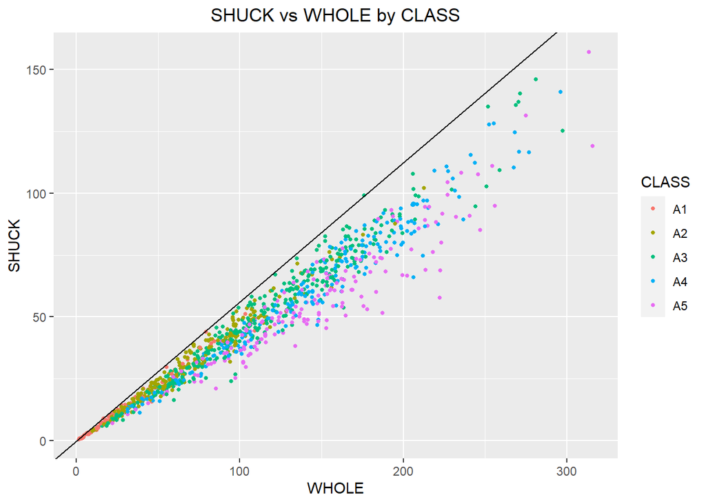

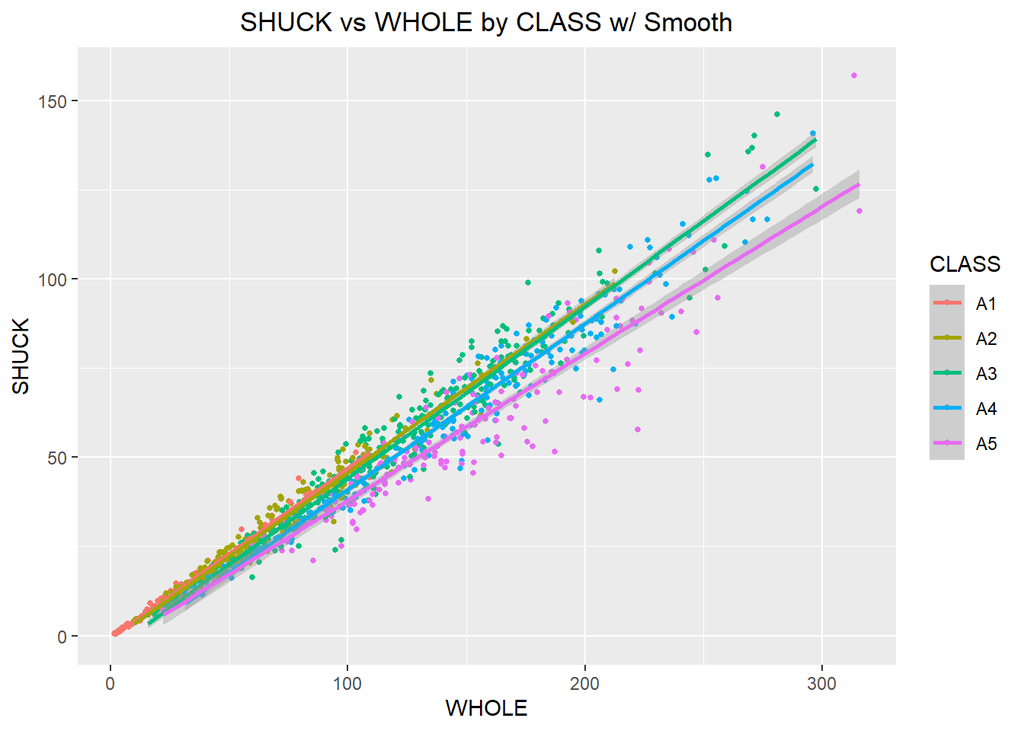

**Essay Question (2 points): How does the variability in this plot differ from the plot in (a)? Compare the two displays. Keep in mind that SHUCK is a part of WHOLE. Consider the location of the different age classes.**

Plot B shows that the Shuck-Whole relationship differs slightly from the Volume-Whole relationship. When considering class, there is a lot more variability as well for Plot B. For Plot A, only A5 stands out as a separate line while in Plot B, the lines differ for A3, A4, A5 visually.

Looking at how the classes differ, it raises a question about the relation between shuck-whole, and volume-whole. A3 (assuming this is prime age) sits higher for shuck-whole, while A5 sits lower. When looking at volume though, A5 sits highest while A1-4 sit together. Does Volume increase when hitting A5 because the abalones are as big as they’ll get shell size? Then weight drops because the flesh reduces when older? Or does the shell thin out while still increasing in size much like bones lose density?

*### Section 3: (8 points) Getting insights about the data using graphs.*

(3)(a) (2 points) Use “mydata” to create a multi-figured plot with histograms, boxplots and Q-Q plots of RATIO differentiated by sex. This can be done using *par(mfrow = c(3,3))* and base R or *grid.arrange()* and ggplot2. The first row would show the histograms, the second row the boxplots and the third row the Q-Q plots. Be sure these displays are legible.

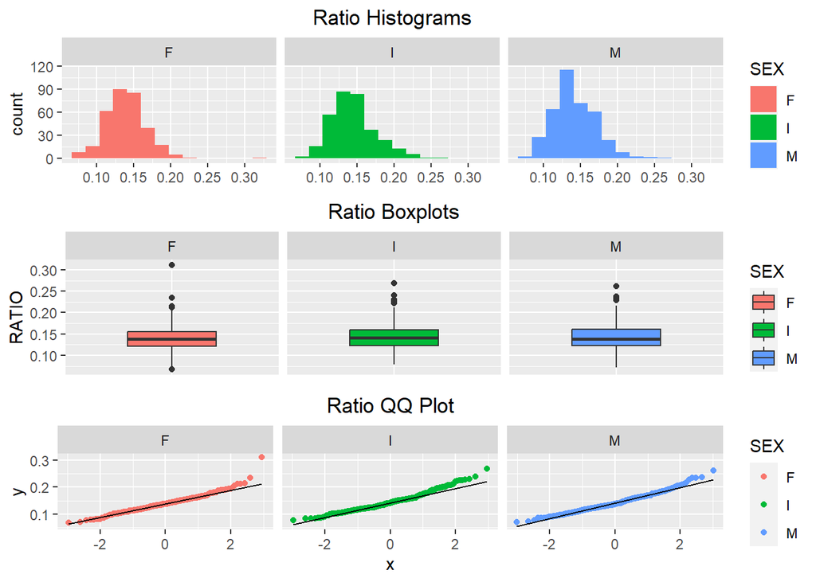

**Essay Question (2 points): Compare the displays. How do the distributions compare to normality? Take into account the criteria discussed in the sync sessions to evaluate non-normality.**

*Looking at the charts, both infants and males look to be slightly right skewed with both ends of the data rising above the line. Females look to be less tailed with the vast only a few outliers deviating from the line. Overall, these look like normal distributions with a slight skew.*

(3)(b) (2 points) The boxplots in (3)(a) indicate that there are outlying RATIOs for each sex. *boxplot.stats()* can be used to identify outlying values of a vector. Present the abalones with these outlying RATIO values along with their associated variables in “mydata”. Display the observations by passing a data frame to the kable() function. Basically, we want to output those rows of “mydata” with an outlying RATIO, but we want to determine outliers looking separately at infants, females and males.

Female Outliers for RATIO

|  | SEX | LENGTH | DIAM | HEIGHT | WHOLE | SHUCK | RINGS | CLASS | VOLUME | RATIO | ratio_shuck_whole |
| --- | --- | --- | --- | --- | --- | --- | --- | --- | --- | --- | --- |
| 350 | F | 7.980 | 6.720 | 2.415 | 80.9375 | 40.37500 | 7 | A2 | 129.5058 | 0.3117620 | 0.4988417 |
| 379 | F | 15.330 | 11.970 | 3.465 | 252.0625 | 134.89812 | 10 | A3 | 635.8278 | 0.2121614 | 0.5351773 |
| 420 | F | 11.550 | 7.980 | 3.465 | 150.6250 | 68.55375 | 10 | A3 | 319.3656 | 0.2146560 | 0.4551286 |
| 421 | F | 13.125 | 10.290 | 2.310 | 142.0000 | 66.47062 | 9 | A3 | 311.9799 | 0.2130606 | 0.4681030 |
| 458 | F | 11.445 | 8.085 | 3.150 | 139.8125 | 68.49062 | 9 | A3 | 291.4784 | 0.2349767 | 0.4898748 |
| 586 | F | 12.180 | 9.450 | 4.935 | 133.8750 | 38.25000 | 14 | A5 | 568.0234 | 0.0673388 | 0.2857143 |

Male Outliers for RATIO

|  | SEX | LENGTH | DIAM | HEIGHT | WHOLE | SHUCK | RINGS | CLASS | VOLUME | RATIO | ratio_shuck_whole |
| --- | --- | --- | --- | --- | --- | --- | --- | --- | --- | --- | --- |
| 746 | M | 13.440 | 10.815 | 1.680 | 130.2500 | 63.73125 | 10 | A3 | 244.1940 | 0.2609861 | 0.4892994 |
| 754 | M | 10.500 | 7.770 | 3.150 | 132.6875 | 61.13250 | 9 | A3 | 256.9928 | 0.2378764 | 0.4607254 |
| 803 | M | 10.710 | 8.610 | 3.255 | 160.3125 | 70.41375 | 9 | A3 | 300.1536 | 0.2345924 | 0.4392281 |
| 810 | M | 12.285 | 9.870 | 3.465 | 176.1250 | 99.00000 | 10 | A3 | 420.1415 | 0.2356349 | 0.5621008 |
| 852 | M | 11.550 | 8.820 | 3.360 | 167.5625 | 78.27187 | 10 | A3 | 342.2866 | 0.2286735 | 0.4671205 |

Infant Outliers for RATIO

|  | SEX | LENGTH | DIAM | HEIGHT | WHOLE | SHUCK | RINGS | CLASS | VOLUME | RATIO | ratio_shuck_whole |
| --- | --- | --- | --- | --- | --- | --- | --- | --- | --- | --- | --- |
| 3 | I | 10.080 | 7.350 | 2.205 | 79.37500 | 44.0000 | 6 | A1 | 163.364040 | 0.2693371 | 0.5543307 |
| 37 | I | 4.305 | 3.255 | 0.945 | 6.18750 | 2.9375 | 3 | A1 | 13.242072 | 0.2218308 | 0.4747475 |
| 42 | I | 2.835 | 2.730 | 0.840 | 3.62500 | 1.5625 | 4 | A1 | 6.501222 | 0.2403394 | 0.4310345 |
| 58 | I | 6.720 | 4.305 | 1.680 | 22.62500 | 11.0000 | 5 | A1 | 48.601728 | 0.2263294 | 0.4861878 |
| 67 | I | 5.040 | 3.675 | 0.945 | 9.65625 | 3.9375 | 5 | A1 | 17.503290 | 0.2249577 | 0.4077670 |
| 89 | I | 3.360 | 2.310 | 0.525 | 2.43750 | 0.9375 | 4 | A1 | 4.074840 | 0.2300704 | 0.3846154 |
| 105 | I | 6.930 | 4.725 | 1.575 | 23.37500 | 11.8125 | 7 | A2 | 51.572194 | 0.2290478 | 0.5053476 |
| 200 | I | 9.135 | 6.300 | 2.520 | 74.56250 | 32.3750 | 8 | A2 | 145.027260 | 0.2232339 | 0.4341995 |

**Essay Question (2 points): What are your observations regarding the results in (3)(b)?**

*### Section 4: (8 points) Getting insights about possible predictors.*

(4)(a) (3 points) With “mydata,” display side-by-side boxplots for VOLUME and WHOLE, each differentiated by CLASS There should be five boxes for VOLUME and five for WHOLE. Also, display side-by-side scatterplots: VOLUME and WHOLE versus RINGS. Present these four figures in one graphic: the boxplots in one row and the scatterplots in a second row. Base R or ggplot2 may be used.

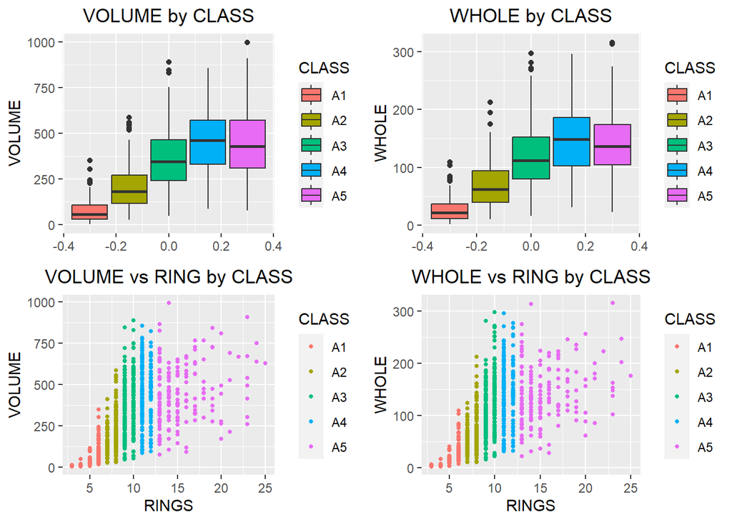

**Essay Question (5 points) How well do you think these variables would perform as predictors of age? Explain.**

*None of these factors look to be well positioned to predict age. The boxplots show the severe overlap in min/max into the neighboring classes’ quartiles. The scatter plots show that the number of rings spans a wide range of values for both volume and whole. We can see the youngest overlapping with the oldest which makes predictions nearly impossible. Looking back to the previous sections, especially the outlier tables we made. It can be seen that there is too much variance in the physical factors that would make predicting age nearly impossible*

*### Section 5: (12 points) Getting insights regarding different groups in the data.*

(5)(a) (2 points) Use *aggregate()* with “mydata” to compute the mean values of VOLUME, SHUCK and RATIO for each combination of SEX and CLASS. Then, using *matrix()*, create matrices of the mean values. Using the “dimnames” argument within *matrix()* or the *rownames()* and *colnames()* functions on the matrices, label the rows by SEX and columns by CLASS. Present the three matrices (Kabacoff Section 5.6.2, p. 110-111). The *kable()* function is useful for this purpose. You do not need to be concerned with the number of digits presented.

```
## [[1]]
## [1] "Volume Table"
##
## [[2]]
## # A tibble: 3 × 6
##   SEX      A1    A2    A3    A4    A5
##   <fct> <dbl> <dbl> <dbl> <dbl> <dbl>
## 1 F     255.   277.  413.  498.  486.
## 2 I      66.5  160.  271.  316.  319.
## 3 M     104.   245.  358.  443.  440.
```

```
## [[1]]
## [1] "Shuck Table"
##
## [[2]]
## # A tibble: 3 × 6
##   SEX      A1    A2    A3    A4    A5
##   <fct> <dbl> <dbl> <dbl> <dbl> <dbl>
## 1 F      38.9  42.5  59.7  69.1  59.2
## 2 I      10.1  23.4  37.2  39.9  36.5
## 3 M      16.4  38.3  53.0  61.4  55.0
```

```
## [[1]]
## [1] "Ratio Table"
##
## [[2]]
## # A tibble: 3 × 6
##   SEX      A1    A2    A3    A4    A5
##   <fct> <dbl> <dbl> <dbl> <dbl> <dbl>
## 1 F     0.155 0.155 0.145 0.138 0.123
## 2 I     0.157 0.148 0.137 0.124 0.117
## 3 M     0.151 0.156 0.146 0.136 0.126
```

(5)(b) (3 points) Present three graphs. Each graph should include three lines, one for each sex. The first should show mean RATIO versus CLASS; the second, mean VOLUME versus CLASS; the third, mean SHUCK versus CLASS. This may be done with the ‘base R’ *interaction.plot()* function or with ggplot2 using *grid.arrange()*.

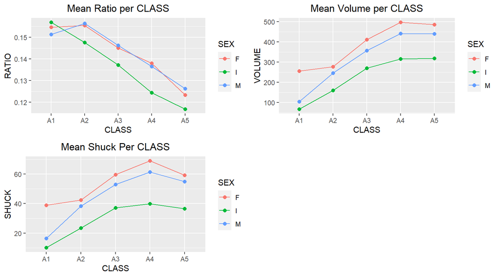

**Essay Question (2 points): What questions do these plots raise? Consider aging and sex differences.**

*One of the questions raised is does shuck peak in A4 for all F/I/M? Another is why do female abalone start at a much heavier shuck weight and volume? How come infants’ ratios do not increase in A2 like F/M*

5(c) (3 points) Present four boxplots using *par(mfrow = c(2, 2)* or *grid.arrange()*. The first line should show VOLUME by RINGS for the infants and, separately, for the adult; factor levels “M” and “F,” combined. The second line should show WHOLE by RINGS for the infants and, separately, for the adults. Since the data are sparse beyond 15 rings, limit the displays to less than 16 rings. One way to accomplish this is to generate a new data set using subset() to select RINGS < 16. Use ylim = c(0, 1100) for VOLUME and ylim = c(0, 400) for WHOLE. If you wish to reorder the displays for presentation purposes or use ggplot2 go ahead.

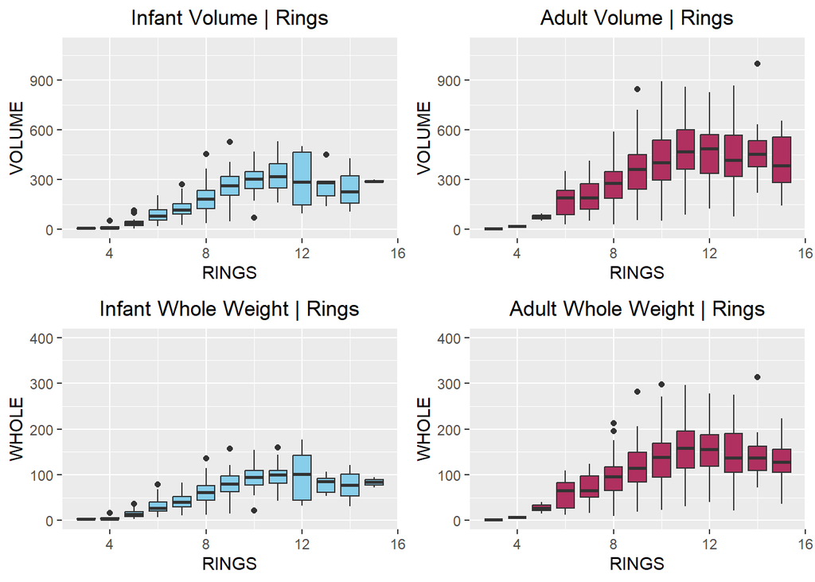

**Essay Question (2 points): What do these displays suggest about abalone growth? Also, compare the infant and adult displays. What differences stand out?**

*It looks like at about 11-12 rings, the weight and volume peaks for infants and adults. At around 8-9 rings the rate of growth also seems to decay. Infants and adults follow the same pattern generally with adult value ranges being wider.*

*### Section 6: (11 points) Conclusions from the Exploratory Data Analysis (EDA).*

**Conclusions**

**Essay Question 1) (5 points) Based solely on these data, what are plausible statistical reasons that explain the failure of the original study? Consider to what extent physical measurements may be used for age prediction.**

*Based on the current analysis, one plausible statistical reason for the failure of the original study is that not enough consideration was given to how different abalone are at different ages. The study could have made the assumption that there is a certain linear/exponential non-log growth factor to abalone much like trees. This assumes that over time, we would see a never ending growth that can be measured and correlated to age. However, the graph of the abalone’s physical characterists show almost a cube root like pattern that makes age only possible to guess in categories, not as a continuous thing.*

*Another possible issue is that the sample has underlying issues. It could be that the above is not true and abalones are like trees where physical measurements can be an effective, somewhat accurate estimate for age. The sample itself could have underlying issues that would give a false impression.*

**Essay Question 2) (3 points) Do not refer to the abalone data or study. If you were presented with an overall histogram and summary statistics from a sample of some population or phenomenon and no other information, what questions might you ask before accepting them as representative of the sampled population or phenomenon?**

*I would need some information on the sampling methodology plus any steps taken to minimize the possible errors. Do the samples meet power requirements, do we know of anything that might be influencing the sample (if we’re measuring radioactiveness of rocks and our sample is taken from Pripyat, it might throw off the results).*

**Essay Question 3) (3 points) Do not refer to the abalone data or study. What do you see as difficulties analyzing data derived from observational studies? Can causality be determined? What might be learned from such studies?**